# Lecture 14：スイッチングコスト、ロイヤルティ、買いだめ

状態依存と買いだめの動学｜計量経済学II

Kei Ikegami

## 今日の流れ（90分）

| 時間 | 内容 |
| --- | --- |
| 10分 | Quiz（解答5分 + 解説5分） |
| 8分 | 導入：2つの謎 |
| 12分 | 状態依存 vs 異質性：似た記述統計は識別ではない |
| 12分 | naive推定はどう間違えるか・2つの対策 |
| 6分 | 状態変数のカタログ |
| 12分 | 在庫モデル：DPを解いて買いだめを見る |
| 12分 | スパイクとdip・短期 vs 長期弾力性 |
| 8分 | 価格差別と反実仮想 |
| 5分 | まとめ・宿題・次回予告 |

## Quiz（前回の復習・10分）

- 配布した Quiz 14 に解答する（**5分**、メモ・ノート参照可）
- そのあと解説（**5分**）
- 採点はしない。前回の内容のセルフチェックとして使うこと

# 導入：2つの謎

## 好みを学ぶことと、行動が状態を変えること

- 第9回：履歴が増えると、その人の固定的な好みについて分かることが増える
- 第13回：現在の行動が将来の状態を変え、その将来を考えて選ぶ
- 今回：同じブランドを買い続ける理由を、固定的な好みと状態依存に分ける
- 一度買ってもらう施策の長期効果は、どちらの仕組みかによって異なる

## 今日押さえたいこと

1. 「同じブランドを買い続ける」持続性は、**本物の状態依存**と**個人異質性**のどちらからも生まれる
2. naiveなpooled logitは、異質性しかない世界でも**偽の状態依存**を検出する
3. 動学logitの固定効果MLEには短パネル問題があり、**Wooldridge型CREは残差REの積分まで必要**
4. 在庫を持てる財では、セールは**将来需要の前借り**（post-promotion dip）
5. 一時的なセールへの反応を恒久的な値下げへの反応と読むと、**この例では長期の反応を過大評価**する

## 謎1：「ロイヤルな顧客」の正体

あるブランドを何度も買い続ける顧客が観測された。これは——

- そのブランドに本当に**引き留める力**がある（ロイヤルティ、スイッチングコスト、学習効果）？
- それとも、**もともとそのブランドが好きな人**が毎回同じものを買っているだけ？

どちらの答えかで、ロイヤルティ施策・顧客獲得投資の価値が**まるで違う**。

## 謎2：セールの「山」の正体

あるセールで売上が大きく伸びた。これは——

- **新しい需要**を掘り起こしたのか？
- それとも、来週買うはずだった人が**前倒しで買っただけ**（未来の需要の前借り）なのか？

どちらの謎も根っこは同じ：**観測された「持続性」や「山」の解釈問題**。見誤ると、効果の薄い獲得施策への大金投入や、利益を毀損する安売り合戦にはまり込む。

## 記法の注意：状態依存パラメータはラムダ

- 第13回と同じく、割引因子は $\beta$、効用パラメータは $\theta$
- 「過去の選択が今日の効用に与える効果」＝**状態依存の強さ**には $\lambda$ を使う
- Euler定数の $\gamma$（第13回のlogsum）と記号がかぶるのを避けるため

# 状態依存 vs 異質性：似た記述統計は識別ではない

## 状態依存の効用式

消費者 $i$ が期 $t$ にブランドAを買うかどうか。効用を

$$u^1_{it}-u^0_{it} = c + \theta_p \, \mathrm{price}_{it} + \lambda \, y_{i,t-1} + \mu_i + \eta_{it}$$

- $y_{i,t-1}$：前期にAを買ったかのダミー。$\lambda > 0$ なら**状態依存（state dependence）**
- $\mu_i$：時間を通じて不変の**個人異質性**（もともとAが好きかどうか）
- $\eta_{it}$：2つの独立なType I極値ショックの差＝ロジスティック分布

## どちらも「買い続ける」を生む

- $\lambda > 0$（状態依存）：前回買った → 今回も買いやすい
- $\sigma_\mu$ 大（異質性）：好きな人はいつも買い、嫌いな人はいつも買わない

観測される結果はどちらも「同じブランドの反復購買」。しかし——

- $\lambda$ の世界：今回の購買が次回を誘発する**追加的な継続経路**がある
- $\mu_i$ の世界：高い反復購買率は、施策の**増分効果の証拠にならない**

どちらでも投資判断には、施策の因果効果と費用を含む増分NPVが必要。

## 初期条件問題（Heckman 1981）

- 最初に観測する選択を $y_{i0}$、推定対象を後続期 $t=1,\dots,T$ と書く
- $y_{i0}$ より前の履歴は見えず、観測される $y_{i0}$ 自体も $\mu_i$ と相関しうる
- **分析者が見始めた時点で、消費者にはすでに歴史がある**

→ $\lambda$ と $\mu_i$ の識別をさらに難しくする

## シミュレーション：2つの正反対のDGP

```r
# (a) 本物の状態依存のみ / (b) 純粋な異質性のみ
dgp_a <- simulate_panel(N, Tn, BURN, lambda = 1.1, sigma_mu = 0.0,
                        const = -0.55, seed = 11)
dgp_b <- simulate_panel(N, Tn, BURN, lambda = 0.0, sigma_mu = 1.4,
                        const = -0.20, seed = 12)
```

- (a)：$\lambda = 1.1$、異質性なし。(b)：$\lambda = 0$、強い異質性（$\sigma_\mu = 1.4$）
- N = 3,000人 × 20期のパネル。バーンイン期間を回してから記録開始
- 定数項は全体購買率が揃うように較正（DGP設計者の特権）

## 集計統計はほぼ区別がつかない

|  | 全体購買率 | P(買う\|前回買った) | P(買う\|前回買わず) | 持続性ギャップ |
| --- | --- | --- | --- | --- |
| (a) 本物の状態依存 (lambda=1.1) | 0.5040 | 0.6340 | 0.3728 | 0.2612 |
| (b) 純粋な異質性 (lambda=0) | 0.4635 | 0.6036 | 0.3422 | 0.2614 |

- 全体購買率も「持続性ギャップ」も、(a)と(b)でほぼ同じ水準
- まったく違うメカニズムが、**選んだ低次の統計では似て見える**

## 記述統計の一致 ≠ 観察的同値

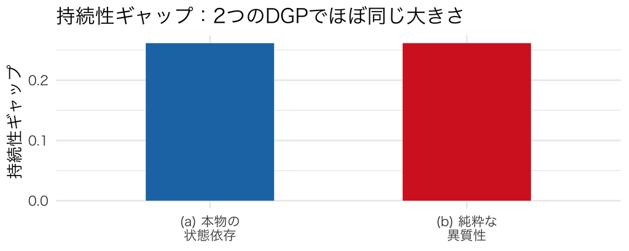

図 1

購買率と1期リピート率だけでは $\lambda$ と $\mu_i$ を分離できない。厳密な**観察的同値**は観測データの同時分布全体が同じことを指し、この図だけでは示していない。

# naive推定はどう間違えるか

## 最も素朴な方法：pooled logit

ラグ選択を説明変数に入れ、全 $(i,t)$ をプールして1本のロジットを推定：

$$\Pr(y_{it}=1 \mid \mathrm{price}_{it}, y_{i,t-1}) = \Lambda(c + \theta_p \, \mathrm{price}_{it} + \lambda \, y_{i,t-1})$$

- $\Lambda(\cdot)$ はロジスティック関数（パラメータの $\lambda$ とは別物）
- `fixest::feglm()` にクラスタ標準誤差を付けて推定するだけ

## naive推定を実行する

```r
fit_naive_a <- feglm(y ~ price + y_lag, data = df_a,
                     family = "binomial", cluster = ~id)
fit_naive_b <- feglm(y ~ price + y_lag, data = df_b,
                     family = "binomial", cluster = ~id)
```

| DGP | lambda_hat | se |
| --- | --- | --- |
| (a) 本物の状態依存 (真のlambda=1.1) | 1.092 | 0.018 |
| (b) 純粋な異質性 (真のlambda=0) | 1.090 | 0.028 |

- DGP (a)：真値1.1近辺を回収（異質性がないので問題ない）
- DGP (b)：**真の $\lambda$ は0なのに、推定値は1近くの大きなプラス**

## なぜ偽の状態依存が出るのか

- $\mu_i$ が大きい人（もともとAが好き）は、前期も今期も買う確率が高い
- 分析者は $\mu_i$ を観測できない
- すると「前期買った」という変数が、**「もともと好きな人だ」というシグナル**（$\mu_i$ の代理変数）として働いてしまう

「ラグ選択の係数がプラスで有意 → state dependenceあり」という報告は、$\lambda > 0$ を識別する**十分な証拠ではない**。$\lambda = 0$ でも簡単に有意なプラスが出る。

## 対策(i)：固定効果logitは「どの推定法か」を区別

| 方法 | 短い $T$ での論点 |
| --- | --- |
| 動学logitの個人ダミーMLE | incidental parametersと初期条件 |
| 静学conditional logit | 固定効果を消せるが、動学版へそのまま流用不可 |
| 動学線形FE | 非線形でなくてもNickell bias |

バイアスの符号はDGP依存。「FEは必ず逆方向」「線形FEなら常に安全」と覚えない。

## 対策(ii)：Wooldridge型CREの仮定

$$\mu_i=a_0+a_1y_{i0}+a_2\bar p_i+r_i,
\qquad r_i\mid y_{i0},\mathbf p_i\sim N(0,\sigma_r^2)$$

- $y_{i0}$ と外生価格履歴で、未観測効果の**条件付き平均**を記述
- それでも残る $r_i$ が、同じ人の全期間に共通
- 正規・線形という補助分布と、価格の厳密外生性が仮定

## 個人尤度：積のあとに積分

$$L_i(\theta)=\int\prod_{t=1}^{T}
P_{it}(r)^{y_{it}}\{1-P_{it}(r)\}^{1-y_{it}}
\phi(r;0,\sigma_r^2)\,dr$$

1. 求積点 $r_q$ を1つ固定
2. その人の全期間のlog確率を合計
3. 求積点を重み付きで足す（Gauss–Hermite）
4. 最後に個人を足す

$y_{i0}$ と $\bar p_i$ をpooled logitへ足すだけでは、$\sigma_r=0$ と置いている。**残差REを積分して初めてCRE**。

## CREにも診断が要る

- 求積点数（例：8・12・16）を変えて $\hat\lambda$ が安定するか
- 正規分布・線形条件付き平均の誤指定に敏感でないか
- $y_{i0}$ の定義と、価格の厳密外生性が妥当か
- 多峰性に備え、最適化の初期値を変えて同じ解へ収束するか

CREは、**初期値に条件づけた未観測効果の分布を指定し、その残差を尤度で積分するモデル**である。

## 実証研究：Dubé, Hitsch and Rossi (2010)

- **問い**：スキャンパネルの強い持続性は本物の慣性か、異質性か
- **モデル**：ランダム係数で異質性を柔軟に許容し、初期条件問題にも対処した構造モデル
- **発見**：丁寧にコントロールしても**有意な状態依存は残る**。ただしその大きさは、素朴な推定が示す値より**かなり小さい**

ロックイン効果の過大評価は、顧客獲得の値引き投資を過大に正当化する。「一度獲得すればずっと囲い込める」という前提が過大なら、獲得コストの予算上限も過大になる。

## 一度買ってもらうと、その後も買うか

同じ好みの分布で、初期の購入状態だけを変える。

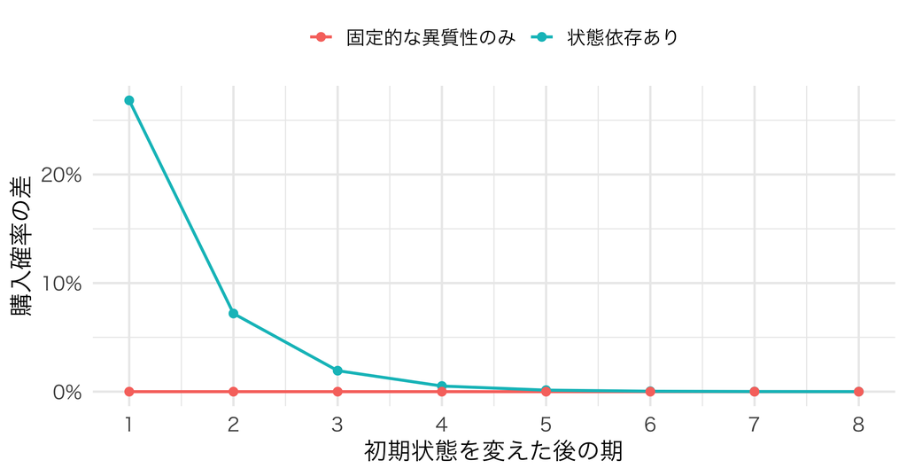

同じ好みの分布で初期の購入状態だけを変える。異質性だけのモデルでは、以後の購入確率は変わらない。

# 状態変数のカタログ

## 「状態」に何を取るか：同じ枠組みのバリエーション

| 状態変数 | 何を捉えるか | 代表的な研究 |
| --- | --- | --- |
| 前回の選択 | ロイヤルティ・慣性 | Dubé, Hitsch and Rossi (2010) |
| 品質についての信念 | 使ってみて分かる学習 | Erdem and Keane (1996) |
| 参照価格（価格の記憶） | 基準からのズレへの反応 | 行動経済学的モデル |
| 在庫水準（後半の主役） | 買いだめ・購買タイミング | Hendel and Nevo (2006) |
| 累積使用経験 | スイッチングコストそのもの | 携帯・保険の乗り換え研究 |

## 学習と参照価格：頭の中が状態になる

- **Erdem and Keane (1996)**：消費者は品質を完全には知らず、使用経験からベイズ更新
  - 状態＝頭の中の**品質の事後分布**（平均と分散）
  - お試しプロモーションには「値引き効果」と別に**「情報を得させる効果」**がある
- **参照価格**：過去に見た価格の記憶が状態。絶対水準より「基準からの乖離」に反応する

## ビジネスの現場で：解約率が低い、は自慢になるか

サブスク・携帯キャリアの「解約率が低い」を見て「ロイヤルティが高い」と言うのは早計。

- **本物のスイッチングコスト**：手続きの手間・学習コスト → 乗り換え反応を弱めるメカニズム
- **異質性**：もともと乗り換えに興味のない層 → 観測された安定だけで競合参入への反応はわからない

第13回の「解約金のあるサブスク解約」（契約残期間という状態）と直結する論点。

# 買いだめとセール：在庫モデル

## 在庫モデルの直感

在庫を持てる財（洗剤・缶詰・トイレットペーパー）の購買：

- 通常価格 → 必要な分だけ、その都度買う（just-in-time）
- **セール** → 「今のうちに多めに買っておこう」＝**買いだめ（stockpiling）**

第13回との対応：

- 状態 $x$：走行距離 → **在庫水準**
- 行動 $a$：交換する/しない → **今期の購入量**
- Zurcherは $x$ が増えるほど維持費がかさむ。消費者は $x$ が減るほど欠品リスクが高まる

## モデルの部品

- 状態：在庫 $x \in \{0, 1, \ldots, 5\}$。行動：購入量 $a \in \{0, 1, 2, 3\}$
- 価格：通常価格、または確率 1/8 でセール（25%引き）
- フロー効用（場合分けは箇条書きで）：
  - 消費機会が来て在庫があれば、消費から効用 $u_c$
  - 購入コスト：価格 × 購入量
  - 保有コスト：期末在庫に比例（保管・鮮度劣化）
  - 欠品ペナルティ：消費機会があるのに在庫ゼロ

$$V(x) = E_p\left[ \max_{a} \left( \bar{u}(x, a, p) + \beta \, E\left[ V(x') \mid x, a, p \right] \right) \right]$$

## 1期の順番を固定する

1. 期首在庫 $x$ と価格 $p$ を観測
2. 購入量 $a$ を選び、購入後在庫は $x+a$
3. 確率 $q(x+a)$ で消費機会が来る
4. 在庫があれば1単位消費、なければ**この枝だけ**欠品損失
5. 期末在庫 $x'$ を次期へ渡す

消費機会が来なかった枝には、欠品ペナルティを入れない。

## DPを解く：政策関数が「買いだめ」を語る

```r
# 行 = 価格の状態、列 = 在庫 x = 0..5 のときの最適購入量 a*(x)
rbind(regular = dp_sol$policy[1, ], sale = dp_sol$policy[2, ])
```

```
        [,1] [,2] [,3] [,4] [,5] [,6]
regular    1    0    0    0    0    0
sale       2    1    0    0    0    0
```

- 通常価格：在庫ゼロなら1単位だけ（just-in-time）
- セール価格：在庫が少ないと**多めに買う**＝買いだめ
- 在庫が多いと、セールでもこれ以上は買わない（保有コストとのトレードオフ）

## 政策関数の図

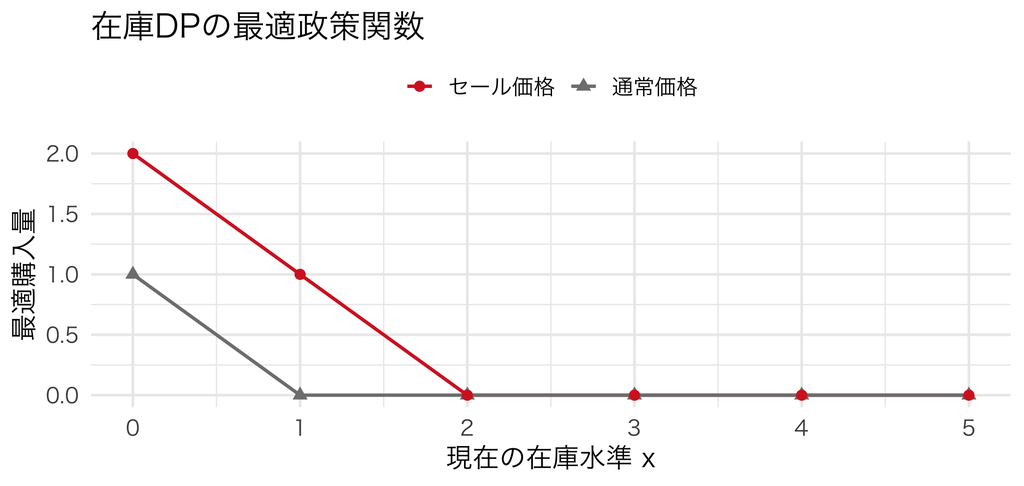

図 2

「買いだめ」は非合理な行動ではなく、**forward-lookingな消費者の最適政策関数**そのもの。第13回のZurcherのS字の交換方針と同じ身分の対象である。

# スパイクとdip・短期 vs 長期弾力性

## 多数の消費者を集計する

- 政策関数に従う **10,000世帯**をシミュレーションし、週次の販売数量系列を作る
- 孤立したセールイベント（**10週目だけセール**）を挟み、前後の売上を見る

各世帯は在庫を見て、通常価格なら通常の政策、セールなら買いだめの政策に従う。

## セールスパイクと post-promotion dip

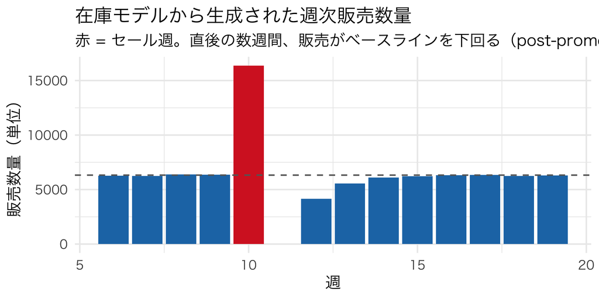

図 3

- セール週に**スパイク**、直後に**dip**：買いだめがあると生じうる形
- 買いだめした消費者が、しばらく在庫を消費するだけで買いに来ない

## ビジネスの現場で：dipだけで成否を決めない

> 「セール直後に売上が落ちた。セールの効果はマイナスだったのでは？」
- dipは買いだめによる需要の前倒しと**整合的**だが、それ自体は成功の証拠ではない
- 十分な観測窓で、無施策の反実仮想に対する**増分の累積数量・売上・粗利**で判断する

## 短期弾力性と長期弾力性は別物

- **短期弾力性**：今週だけの価格変化に対する、**今週の**数量対数変化の比
- **長期弾力性**：**恒久的な**価格レジーム間の、定常数量対数変化の比

大きな離散変化では、どちらも $\log(Q_1/Q_0)/\log(P_1/P_0)$ で測り、log-log回帰係数と尺度をそろえる。

買いだめが強い財では、この2つは大きく乖離する：

- 短期：セールに反応した買いだめ分が、まるごと数量増として観測される
- 長期：**1人が消費できる量には上限がある**。恒久値下げは総消費をほぼ増やさない

## 3つの対象を混ぜない

| 対象 | 変えるもの | 消費者の政策関数 |
| --- | --- | --- |
| 短期弾力性 | 今週だけの不意打ち価格 | 基準レジームの政策 |
| 静学回帰係数 | 実現した一時的セールと当週数量 | データから回帰 |
| 長期弾力性 | 恒久的な価格レジーム | **各レジームでDPを解き直す** |

「ずっとセール」と知る消費者に、基準のセール確率で解いた政策関数を使わせてはいけない。

## 静学推定はどう間違えるか

週次の価格と数量に log-log 回帰 →「価格弾力性」を報告——実務の定番だが：

- 静学回帰は「価格が動いた週に何が起きたか」しか見ていない＝**実質的に短期の反応**
- それを恒久的な値下げの試算に使うと、一時的な購入の前倒しまで長期の需要増と数えてしまう

在庫を持てる財では、セールで増えた購入の一部は**将来の購入の前倒し**である。一時的なセールへの反応を恒久的な値下げへの反応と読むと、**この例では長期の反応を過大評価する**。大きさや方向は、モデルと比較する価格変化に依存する。

## 実証研究：Hendel and Nevo (2006)

- **問い**：洗濯用洗剤のようなストック可能財で、在庫行動を無視した需要推定は何をどれだけ見誤るか
- **データ**：米国の洗剤カテゴリの世帯スキャンパネル
- **モデル**：消費者がセールを見越して購買タイミングを最適化する動学的需要モデル（今日のRシミュの本格版）
- **発見**：この研究の洗剤データでは、在庫行動を無視した静学モデルが価格反応を大きく推定する。短期の購入増を、新たな消費量の増加と区別する必要がある

# 価格差別と反実仮想

## Pigouの「次数」とVarianによる整理

- **1次**：各消費者の支払意思額をそのまま個別請求（理想形、ほぼ不可能）
- **2次**：メニューを自分で選ばせる（大容量割引、松竹梅プラン）
- **3次**：観測可能な属性でグループ分け（学生割・シニア割・地域価格）

購買履歴ベース価格は設計次第：粗い履歴グループなら3次に近く、個人別予測WTPへ合わせるならpersonalized pricing（1次への近似）に近い。

## 履歴に基づく価格差別：先に補助、後で回収

初月無料・乗り換え割引・休眠顧客への「お帰りなさいクーポン」——すべて**過去の行動（状態）を見て価格を変える**動学的価格戦略の最も単純な形。

本物のスイッチングコスト（$\lambda > 0$）があるなら：

> まず補助金を払って獲得し、後で（スイッチングコストに守られて）回収する
- $\lambda$ は将来の継続購買を決める重要な入力の1つ。ただし、戦略の採算は因果的な獲得増・獲得費用・将来マージン・ベースライン継続率・離脱・競争との**増分NPV**で決まる

## 反実仮想：セール頻度を2倍にしたら

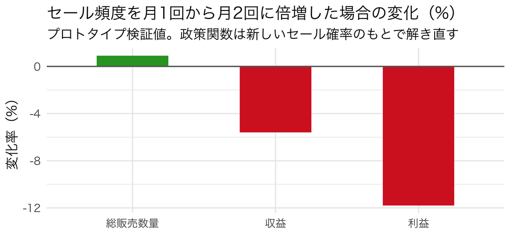

図 4

- 総販売数量は**ほぼ不変**（在庫上限が効く）。収益は約6%減、利益は約12%減
- 通常価格で売れていた需要を、安値販売に置き換えるだけ

## 反実仮想：初回割引は増分NPVで評価

- この単純モデルで$\lambda = 1.1$なら、初回のトライアル割引が状態依存を通じて**その後の累積的な追加購買**を生む
- 同じ単純モデルで$\lambda = 0$なら、この経路による**2期目以降の増分はない**（学習・広告など別経路はモデル外）

$\lambda$を過大評価すると後続購買を水増しし、LTV試算は楽観側に傾く。しかし投資判断には、因果的な獲得増、値引き・獲得費用、将来マージン、ベースライン継続率と顧客異質性、離脱、競合反応を合わせた**増分NPV**が必要である。

## EDLPかHi-Loか：買いだめの視点

小売の大論争を今日の道具で整理：

- **Hi-Lo**（通常は高め、時々大幅値下げ）：セールのたびに買いだめとdipを誘発。顧客が価格パターンを学習すると「安くなるまで待つ」が定着するリスク
- **EDLP**（毎日安売り）：買いだめのタイミングゲームを排除。ただしセールの話題性・集客効果は失う

どちらが有利かは、**カテゴリの買いだめのしやすさ**（保存性、パントリーの大きさ）に依存する。

# まとめ

## この回の要点

- 持続的な反復購買は、状態依存 $\lambda$ と異質性 $\mu_i$ の**どちらからも**生まれる。少数の記述統計の一致だけで観察的同値とは言えない
- naive pooled logitは偽の状態依存を検出する。動学FEには短パネル問題があり、Wooldridge型CREでは**残差REを個人尤度で積分**する
- 学習・参照価格・スイッチングコスト・在庫は、すべて「状態変数の選び方」のバリエーション
- 買いだめ財では、セールは将来需要の前借り（スパイクとpost-promotion dip）
- 一時的セールの静学回帰と恒久価格の長期反応は別の対象。恒久反実仮想ではDPを解き直す
- 履歴に基づく価格差別（先に補助、後で回収）は、$\lambda$を含む継続経路と獲得増・費用・将来マージン・離脱・競争を合わせた増分NPVで評価する

## 宿題

- CREコードでDGP (b) の $\sigma_\mu$ と求積点数を変え、$\hat\lambda$・$\hat\sigma_r$の感度を見る
- 在庫モデルの `c_hold`（保有コスト）を大きくすると、セール時の買いだめはどう変わるか確認する
- 身の回りの「初回割引」を1つ挙げ、状態依存に加えて増分NPVの評価に必要な獲得効果・費用・将来マージン・離脱・競争の情報を考える
- 生成AIに「state dependenceと個人の異質性はどう見分けるか」と聞き、今日の内容と突き合わせる
- **coding課題は `assignment14.qmd`**：ブランド選択パネルのDGP → naive推定 → CRE → 在庫DGPの反実仮想まで統合

## 次回予告：企業側の動学へ

- 第13〜14回は**消費者側**の動学だった。第15回は視点を転換し、**企業側の動学的価格設定（dynamic pricing）**へ
- 今日と同じDPの道具を、次回は残席・残在庫を持つ売り手の利益最大化へ再利用する
- 次回は2期間の値下げ待ちと価格設定から始め、その後、企業の在庫と期限を状態とするモデルを解く

**Reading**：Hendel and Nevo (2006)、Dubé, Hitsch and Rossi (2010)